# Tree-BasedMethods Exercises Ch 8

Darshan Patel

2/21/2019

The following set of problems are from the applied exercises section in ISLR Chapter 8: Tree-Based Methods.

```r
rm(list = ls())
library(MASS)
library(ISLR)
library(tidyverse)
library(GGally)
library(tree)
library(randomForest)
library(gbm)
library(glmnet)
library(class)
```

## Question 7: Using the `Boston` dataset, create a plot displaying the test error resulting from random forests on this data set for a comprehensive range of values for `mtry` and `ntree`. Describe the results obtained.

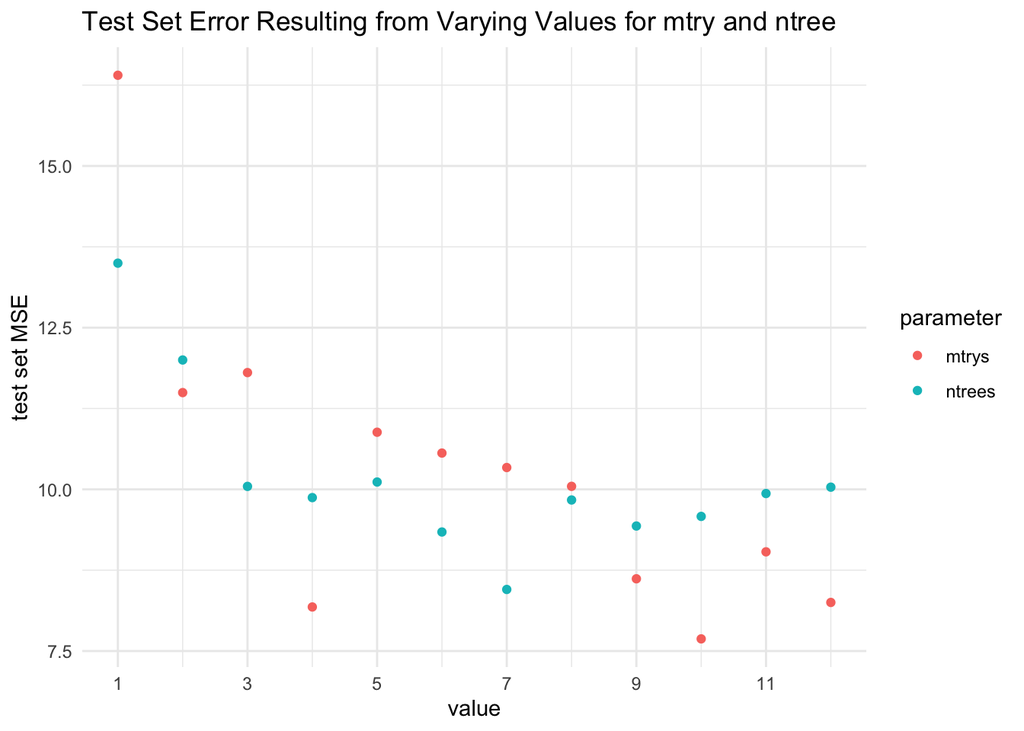

```r
df = Boston
set.seed(7)
indices = sample(1:nrow(df), size = 0.7*nrow(df))
train = df[indices,]
test = df[-indices,]
mtrys = c()
ntrees = c()
for(i in 1:12){
  temp_rf = randomForest(medv~., data = train,
                         mtry = 10, ntree = i)
  mtrys = c(mtrys, mean((predict(temp_rf, test) - test$medv)^2))
  temp_rf2 = randomForest(medv~., data = train,
                          mtry = i, ntree = 10)
  ntrees = c(ntrees, mean((predict(temp_rf2, test) - test$medv)^2))
}
rf_stats_df = data.frame(x = 1:12, mtrys, ntrees)
rf_stats_df %>% gather(parameter, mse, mtrys, ntrees) %>%
  ggplot(aes(x = x, y = mse, color = parameter)) + geom_point() +
  labs(x = "value", y = "test set MSE") +
  scale_x_continuous(breaks = seq(1, 12, by = 2)) +
  ggtitle("Test Set Error Resulting from Varying Values for mtry and ntree") +
  theme_minimal()
```

## Question 8: Using the `Carseats` dataset, predict `Sales` using regression trees and related approaches, treating the response as a quantitative variable.

1. Split the data into a training set and a test set.

```r
df = Carseats
set.seed(8)
indices = sample(1:nrow(df), size = 0.7*nrow(df))
train = df[indices,]
test = df[-indices,]
```

2. Fit a regression tree to the training set. Plot the tree and interpret the results. What test error rate was obtained?

```r
set.seed(8)
model1 = tree(Sales~., data = train)
mean((predict(model1, test) - test$Sales)^2)
```

```
## [1] 4.454896
```

The test error rate is $4.454$.

The tree is plotted below.

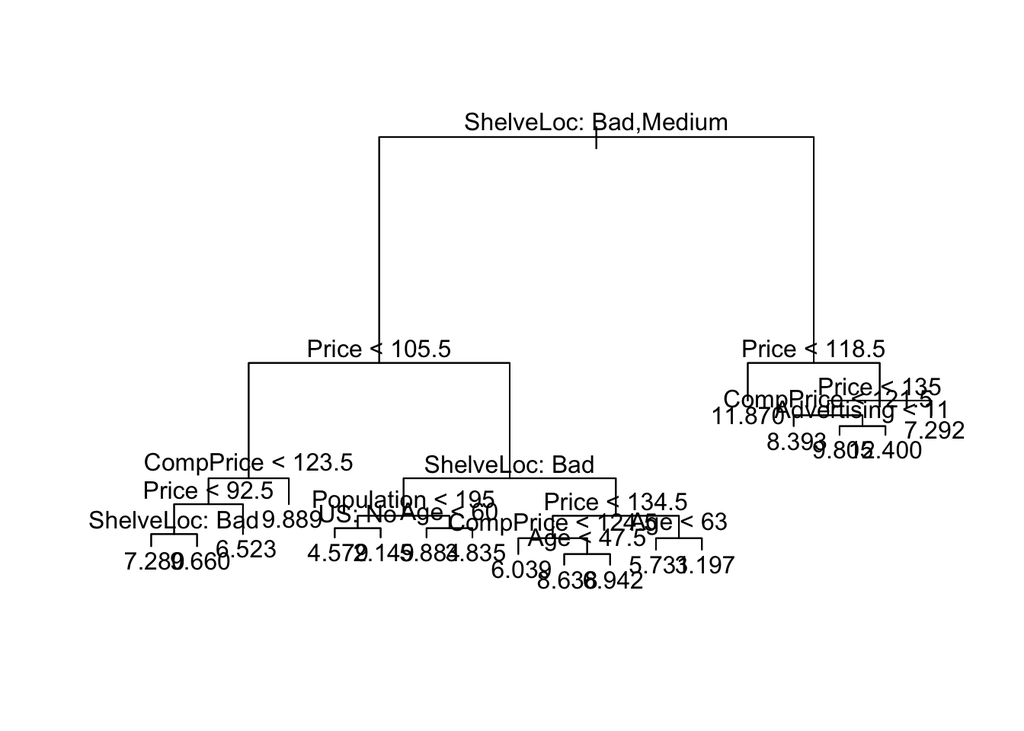

```r
plot(model1)
text(model1, pretty = 0)
```

It appears to be that `ShelveLoc` and `Price` are important indicators of `Sales`.

3. Use cross-validation to determine the optimal level of tree complexity. Does pruning the tree improve the test error rate?

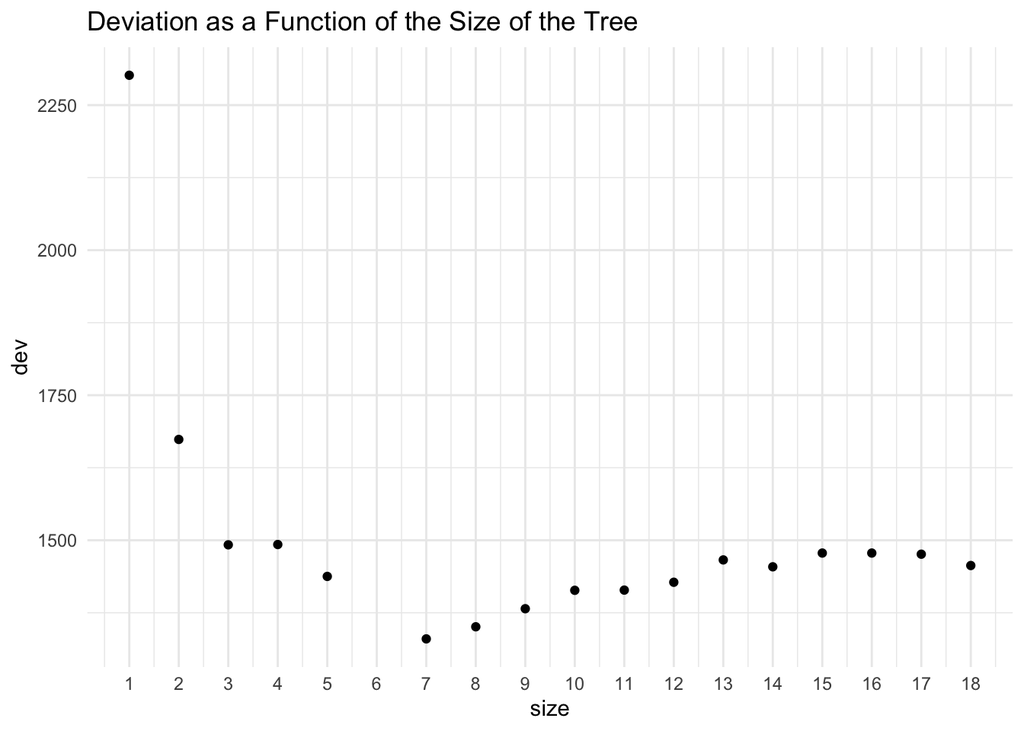

```r
set.seed(8)
model1_cv = cv.tree(model1)
model1_cv_df = data.frame(size = model1_cv$size,
                          dev = model1_cv$dev)
ggplot(model1_cv_df, aes(x = size, y = dev)) + geom_point() +
  scale_x_continuous(breaks = 1:18) +
  ggtitle("Deviation as a Function of the Size of the Tree") +
  theme_minimal()
```

The optimal level of tree complexity is $7$ trees. Now, does pruning help?

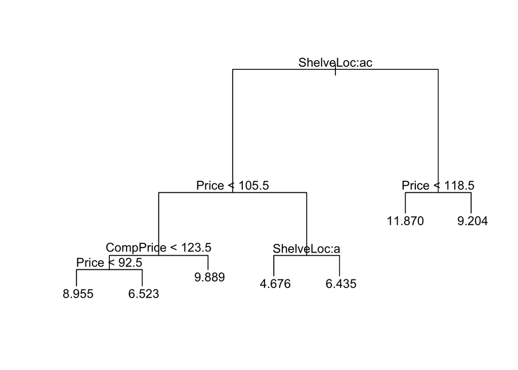

```r
model1_prune = prune.tree(model1, best = 7)
plot(model1_prune)
text(model1_prune)
```

```r
mean((predict(model1_prune, test) - test$Sales)^2)
```

```
## [1] 4.947714
```

The test error rate before pruning is $4.454$. After pruning, it is $4.947714$. Pruning the tree did not help improve the test error rate.

4. Use the bagging approach in order to analyze this data. What test error rate was obtained? use the `importance()` function to determine which variables are most important.

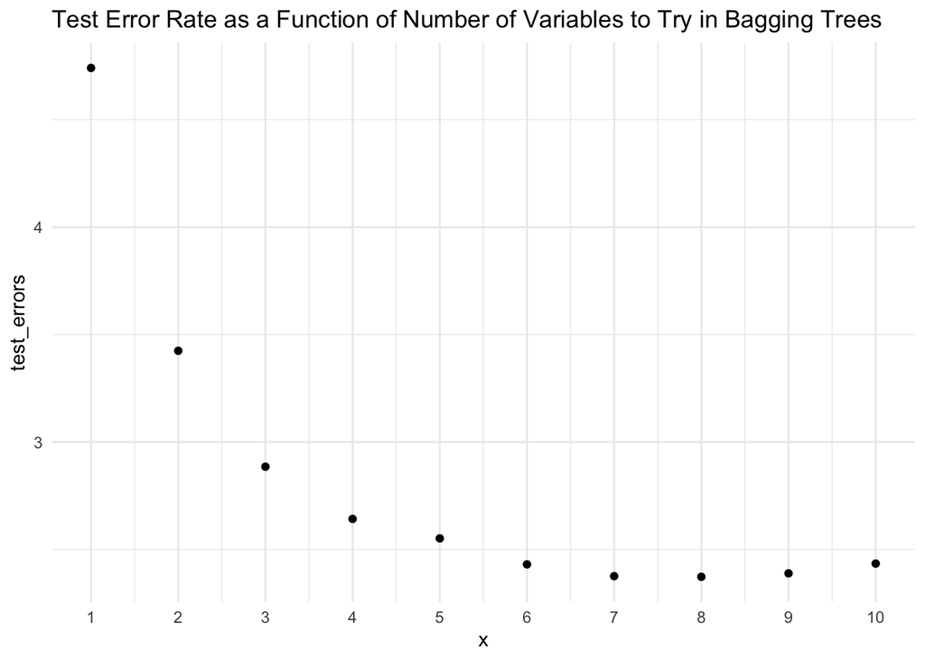

```r
set.seed(8)
test_errors = c()
for(i in 1:10){
  model2 = randomForest(Sales~., data = train,
                        mtry = i, importance = TRUE)
  test_errors = c(test_errors, (mean((predict(model2, test) - test$Sales)^2)))
}
test_errors_df = data.frame(x = 1:10, test_errors)
ggplot(test_errors_df, aes(x = x, y = test_errors)) + geom_point() +
  scale_x_continuous(breaks = 1:10) +
  ggtitle("Test Error Rate as a Function of Number of Variables to Try in Bagging Trees") +
  theme_minimal()
```

The best number of variables to try is $8$.

```r
model2best = randomForest(Sales~., data = train, mtry = 8, importance = TRUE)
importance(model2best)
```

```
##               %IncMSE IncNodePurity
## CompPrice   24.301928     187.70329
## Income      11.510839     138.32149
## Advertising 17.409891     133.58752
## Population  -1.806747      70.14546
## Price       61.432981     660.22020
## ShelveLoc   72.335437     705.84675
## Age         22.185591     204.10714
## Education    1.018820      60.23388
## Urban       -0.924055      10.03622
## US           5.088106      15.15826
```

```r
test_errors = c(test_errors, (mean((predict(model2, test) - test$Sales)^2)))
```

According to this, if `Price` is removed from the model creation, then there is a $61\%$ decrease in the accuracy of out of bag predictions. Likewise, if `ShelveLoc` is removed, then there is a $72\%$ decrease in the accuracy of out of bag prediction. Using this bagged model, the test set MSE is

```r
mean((predict(model2best, test) - test$Sales)^2)
```

```
## [1] 2.384532
```

This test error rate is lower than when a regular regression tree was created as well as after it was pruned.

5. Use random forests to analyze this data. What test error rate was obtained? Use the `importance()` function to determine which variables are most important. Describe the effect of $m$, the number of variables considered at each split, on the error rate obtained.

```r
set.seed(8)
test_errors = c()
for(i in 1:10){
  model3 = randomForest(Sales~., data = train,
                        mtry = i, ntree = 3, importance = TRUE)
  test_errors = c(test_errors, (mean((predict(model3, test) - test$Sales)^2)))
}
test_errors
```

```
##  [1] 5.960655 5.470976 4.673021 4.056446 3.999369 3.740645 2.951587
##  [8] 3.348464 3.312095 3.757623
```

As $m$ increases, or the number of the variables considered at each split, the test error rate decreased until $m=7$. Using the parameter $m=7$,

```r
model3best = randomForest(Sales~., data = train,
                          mtry = 7, ntree = 3, importance = TRUE)
importance(model3best)
```

```
##               %IncMSE IncNodePurity
## CompPrice    6.861041    212.264378
## Income       1.733153    114.597154
## Advertising  2.748178    118.741756
## Population  -1.193387     70.145861
## Price       16.091595    573.077267
## ShelveLoc   30.182280    684.999265
## Age          4.978486    151.967644
## Education   -1.379607     41.706894
## Urban       -1.435928     23.418042
## US          -1.206316      4.297039
```

`ShelveLoc` and `Price` continue to be important predictors for `Sales`.

## Question 9: This problem involves the `OJ` dataset which is part of the `ISLR` package.

1. Create a training set containing a random sample of $800$ observations and a test set containing the remaining observations.

```r
df = OJ
set.seed(800)
indices = sample(1:nrow(df), size = 800)
train = df[indices,]
test = df[-indices,]
```

2. Fit a tree to the training data, with `Purchase` as the response and the other variables except for `Buy` as predictors. Use the `summary()` function to produce summary statistics about the tree and describe the results obtained. What is the training error rate? How many terminal nodes does the tree have?

```r
model4 = tree(Purchase ~ ., data = train)
summary(model4)
```

```
##
## Classification tree:
## tree(formula = Purchase ~ ., data = train)
## Variables actually used in tree construction:
## [1] "LoyalCH"       "PriceDiff"     "ListPriceDiff"
## Number of terminal nodes:  7
## Residual mean deviance:  0.7519 = 596.2 / 793
## Misclassification error rate: 0.1538 = 123 / 800
```

Valuable variables that can predict `Purchase` are `LoyalCH`, `PriceDiff` and `ListPriceDiff`. The training error rate is $0.153$. The tree has $7$ terminal nodes.

3. Type in the name of the tree object in order to get a detailed text output. Pick one of the terminal nodes and interpret the information displayed.

```r
model4
```

```
## node), split, n, deviance, yval, (yprob)
##       * denotes terminal node
##
##  1) root 800 1067.00 CH ( 0.61375 0.38625 )
##    2) LoyalCH < 0.48285 305  333.40 MM ( 0.23607 0.76393 )
##      4) LoyalCH < 0.051325 68   18.05 MM ( 0.02941 0.97059 ) *
##      5) LoyalCH > 0.051325 237  287.70 MM ( 0.29536 0.70464 )
##       10) PriceDiff < 0.31 183  194.70 MM ( 0.22404 0.77596 ) *
##       11) PriceDiff > 0.31 54   74.56 CH ( 0.53704 0.46296 ) *
##    3) LoyalCH > 0.48285 495  424.50 CH ( 0.84646 0.15354 )
##      6) LoyalCH < 0.764572 245  285.50 CH ( 0.73061 0.26939 )
##       12) PriceDiff < 0.085 87  120.50 MM ( 0.48276 0.51724 )
##         24) ListPriceDiff < 0.235 57   71.10 MM ( 0.31579 0.68421 ) *
##         25) ListPriceDiff > 0.235 30   30.02 CH ( 0.80000 0.20000 ) *
##       13) PriceDiff > 0.085 158  123.80 CH ( 0.86709 0.13291 ) *
##      7) LoyalCH > 0.764572 250   83.97 CH ( 0.96000 0.04000 ) *
```

4. Create a plot of the tree and interpret the results.

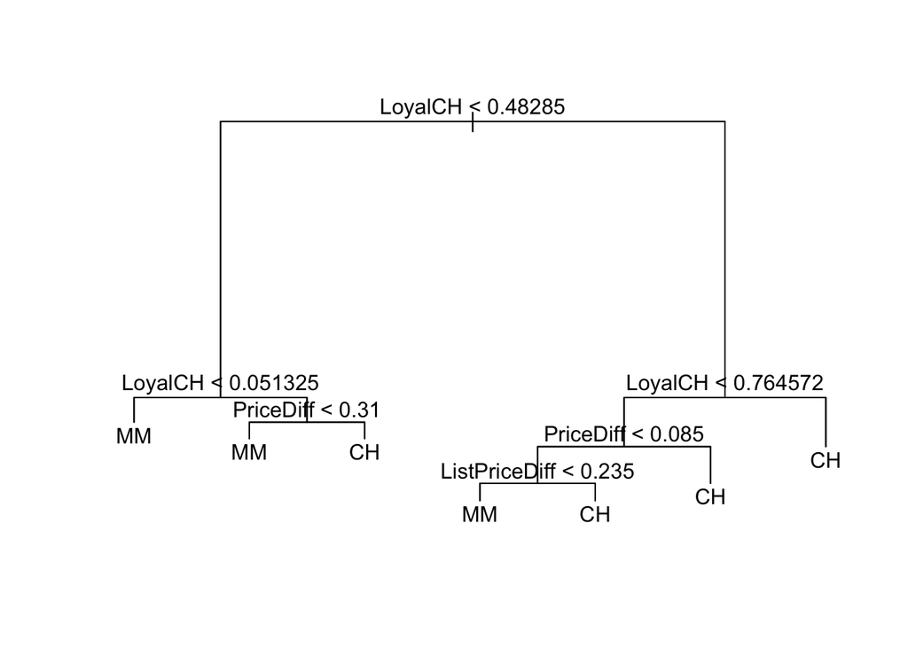

```r
plot(model4)
text(model4)
```

The topmost important criterion is if `LoyalCH` is less than $0.48285$. Further classification is aided by additional segmentation of `LoyalCH` followed by `PriceDiff`.

5. Predict the response on the test data and produce a confusion matrix comparing the test labels to the predicted test labels. What is the test error rate?

```r
predictions = predict(model4, test, type = "class")
table(predictions, test$Purchase)
```

```
##
## predictions  CH  MM
##          CH 137  30
##          MM  25  78
```

According to this model, a good number of correct predictions are made. The test error rate is

```r
(nrow(test) - sum(diag(table(predictions, test$Purchase)))) / nrow(test)
```

```
## [1] 0.2037037
```

This is somewhat high; it can be improved.

6. Apply the `cv.tree()` function to the training set in order to determine the optimal tree size.

```r
model4_cv = cv.tree(model4)
model4_cv
```

```
## $size
## [1] 7 6 5 4 3 2 1
##
## $dev
## [1]  724.7805  699.9392  696.8692  720.8456  733.4632  768.1672 1067.6540
##
## $k
## [1]      -Inf  18.39377  19.38334  27.65907  41.15852  55.03483 309.39449
##
## $method
## [1] "deviance"
##
## attr(,"class")
## [1] "prune"         "tree.sequence"
```

The number of tree sizes considered are from $1$ to $7$.

7. Produce a plot with tree size on the $x$-axis and cross-validated classification error rate on the $y$-axis.

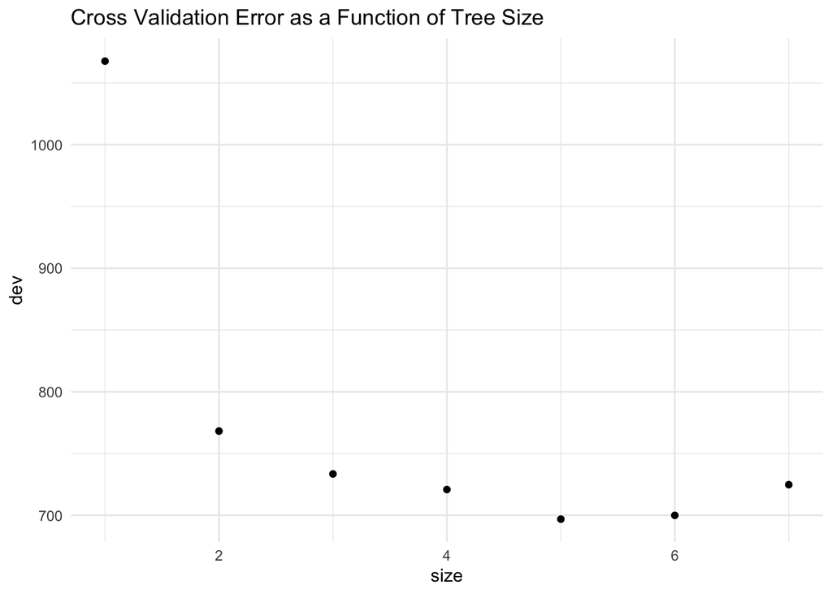

```r
model4_cv_df = data.frame(size = model4_cv$size,
                          dev = model4_cv$dev)
ggplot(model4_cv_df, aes(x = size, y = dev)) + geom_point() +
  ggtitle("Cross Validation Error as a Function of Tree Size") +
  theme_minimal()
```

Misclassification error rate decreases rapidly from a size of $1$ to a size of $2$ and continue to do so until $5$ trees are used and then increases.

8. Which tree size corresponses to the lowest cross-validated classification error rate?

The optimal tree size is $5$ which had the lowest misclassification rate.

1. Produce a pruned tree corresponding to the optimal tree size obtained using cross-validation. If cross-validation does not lead to selection of a pruned tree, then create a pruned tree with five terminal nodes.

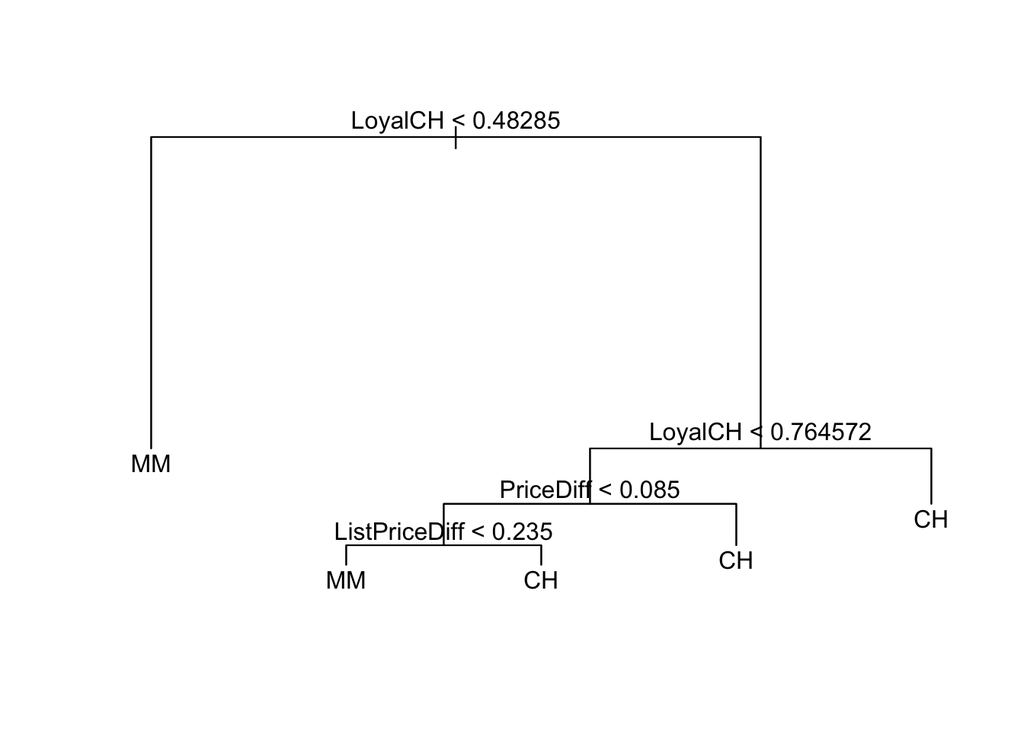

```r
model4_pruned = prune.misclass(model4, best = 5)
plot(model4_pruned)
text(model4_pruned)
```

10. Compare the training error rates between the pruned and unpruned trees. Which is higher?

```r
summary(model4)
```

```
##
## Classification tree:
## tree(formula = Purchase ~ ., data = train)
## Variables actually used in tree construction:
## [1] "LoyalCH"       "PriceDiff"     "ListPriceDiff"
## Number of terminal nodes:  7
## Residual mean deviance:  0.7519 = 596.2 / 793
## Misclassification error rate: 0.1538 = 123 / 800
```

```r
summary(model4_pruned)
```

```
##
## Classification tree:
## snip.tree(tree = model4, nodes = 2L)
## Variables actually used in tree construction:
## [1] "LoyalCH"       "PriceDiff"     "ListPriceDiff"
## Number of terminal nodes:  5
## Residual mean deviance:  0.8079 = 642.3 / 795
## Misclassification error rate: 0.1588 = 127 / 800
```

The training error rate is slightly higher for the pruned tree.

11. Compare the test error rates between the pruned and unpruned trees. Which is higher?

```r
predictions2 = predict(model4, test, type = "class")
(nrow(test) - sum(diag(table(predictions2, test$Purchase)))) / nrow(test)
```

```
## [1] 0.2037037
```

## Question 10: Now using boosting to predict `Salary` in the `Hitters` dataset.

1. Remove the observations for whom the salary information is unknown and then log-transform the salaries.

```r
df = Hitters
df = df[!is.na(df$Salary),]
df$Salary = log(df$Salary)
```

2. Create a training set consiting of the first $200$ observations and a test set consisting of the remaining observations.

```r
indices = 1:200
train = df[indices,]
test = df[-indices,]
```

3. Perform boosting on the training set with $1,000$ trees for a range of values of the shrinkage parameter $\lambda$. Produce a plot with different shrinkage values on the $x$-axis and the corresponding training set MSE on the $y$-axis.

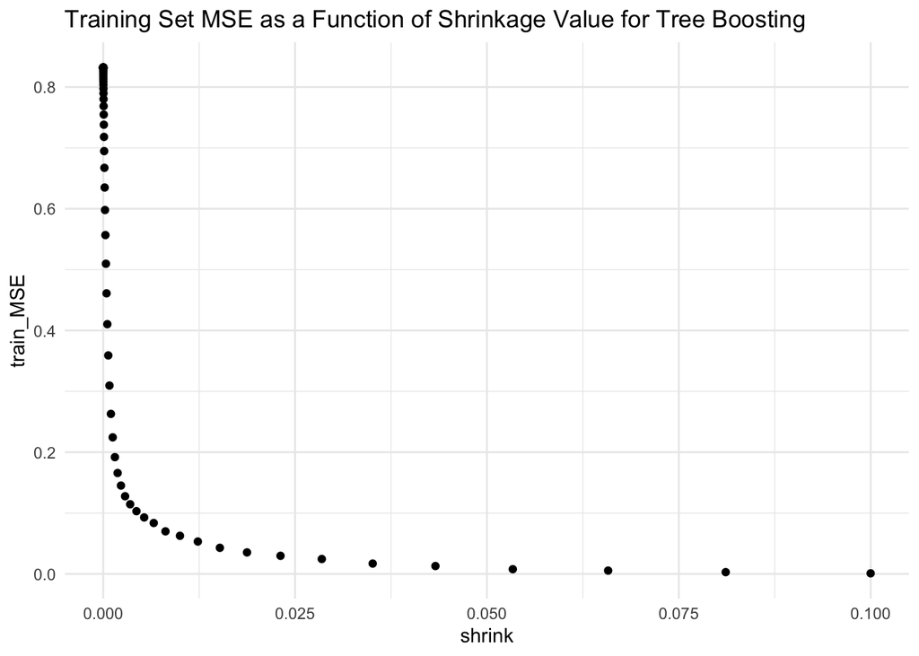

```r
set.seed(1000)
shrink = 10^seq(-10, -1, length = 100)
train_MSE = c()
for(i in shrink){
  model5 = gbm(Salary ~ ., data = train,
               distribution = "gaussian", n.trees = 1000,
               interaction.depth = 4, shrinkage = i)
  train_MSE = c(train_MSE,
                mean((predict(model5, train, n.tree = 1000) - train$Salary)^2))
}
train_MSE_df = data.frame(shrink, train_MSE)
ggplot(train_MSE_df, aes(x = shrink, y = train_MSE)) + geom_point() +
  ggtitle("Training Set MSE as a Function of Shrinkage Value for Tree Boosting") +
  theme_minimal()
```

4. Produce a plot with different shrinkage values on the $x$-axis and the corresponding test set MSE on the $y$-axis.

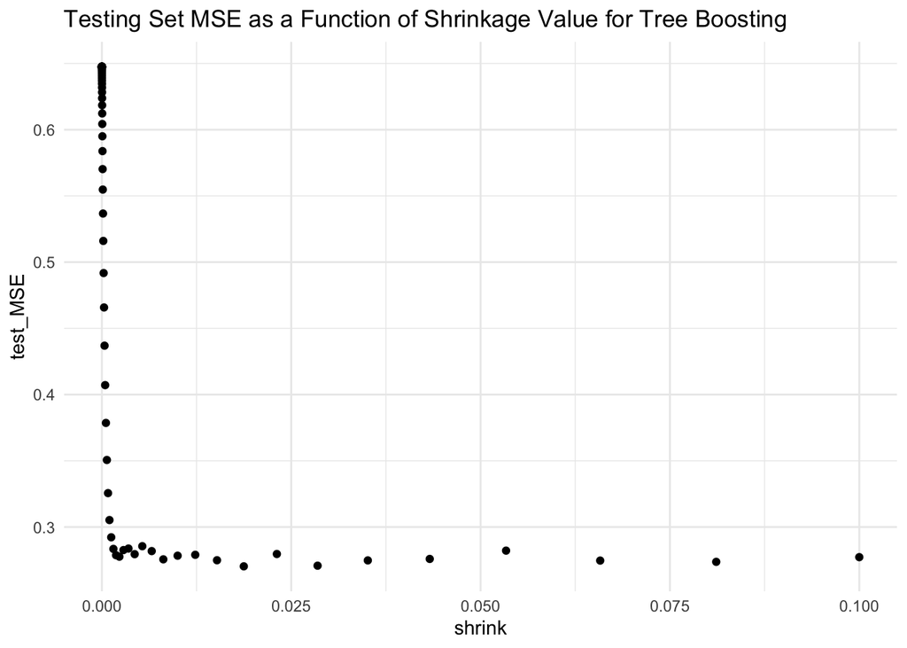

```r
set.seed(1000)
shrink = 10^seq(-10, -1, length = 100)
test_MSE = c()
for(i in shrink){
  model5 = gbm(Salary ~ ., data = train,
               distribution = "gaussian", n.trees = 1000,
               interaction.depth = 4, shrinkage = i)
  test_MSE = c(test_MSE,
               mean((predict(model5, test, n.tree = 1000) - test$Salary)^2))
}
test_MSE_df = data.frame(shrink, test_MSE)
ggplot(test_MSE_df, aes(x = shrink, y = test_MSE)) + geom_point() +
  ggtitle("Testing Set MSE as a Function of Shrinkage Value for Tree Boosting") +
  theme_minimal()
```

Unlike the training set MSE, the test set MSE is not continuously decreasing as shrinking increases. In fact, the lowest test MSE occurs when shrinkage is

```r
shrink[which.min(test_MSE)]
```

```
## [1] 0.01873817
```

and the test set MSE is

```r
min(test_MSE)
```

```
## [1] 0.2703327
```

5. Compare the test MSE of boosting to the test MSE that results from applying two different regression approaches.

```r
train_matrix = model.matrix(Salary~., data = train)
test_matrix = model.matrix(Salary~., data = train)

model5ridge = glmnet(train_matrix, train$Salary,
                     alpha = 0,
                     lambda = 10^seq(10, -2, length = 1000),
                     thresh = 1e-12)
model5_ridge_cv = cv.glmnet(train_matrix, train$Salary,
                            alpha = 0,
                            lambda = 10^seq(10, -2, length = 1000),
                            thresh = 1e-12)
ridge_mse = mean((predict(model5ridge, s = model5_ridge_cv$lambda.min,
                          newx = test_matrix) - test$Salary)^2)

model5lasso = glmnet(train_matrix, train$Salary,
                     alpha = 1,
                     lambda = 10^seq(10, -2, length = 1000),
                     thresh = 1e-12)
model5_lasso_cv = cv.glmnet(train_matrix, train$Salary,
                            alpha = 1,
                            lambda = 10^seq(10, -2, length = 1000),
                            thresh = 1e-12)
lasso_mse = mean((predict(model5lasso, s = model5_lasso_cv$lambda.min,
                          newx = test_matrix) - test$Salary)^2)
```

```r
paste("Ridge MSE", ridge_mse)
```

```
## [1] "Ridge MSE 1.06192052833569"
```

```r
paste("Lasso MSE", lasso_mse)
```

```
## [1] "Lasso MSE 1.11324439396726"
```

The test set of boosting is lower than the ones found using ridge and lasso regression.

6. Which variables appear to be the most important predictors in the boosted model?

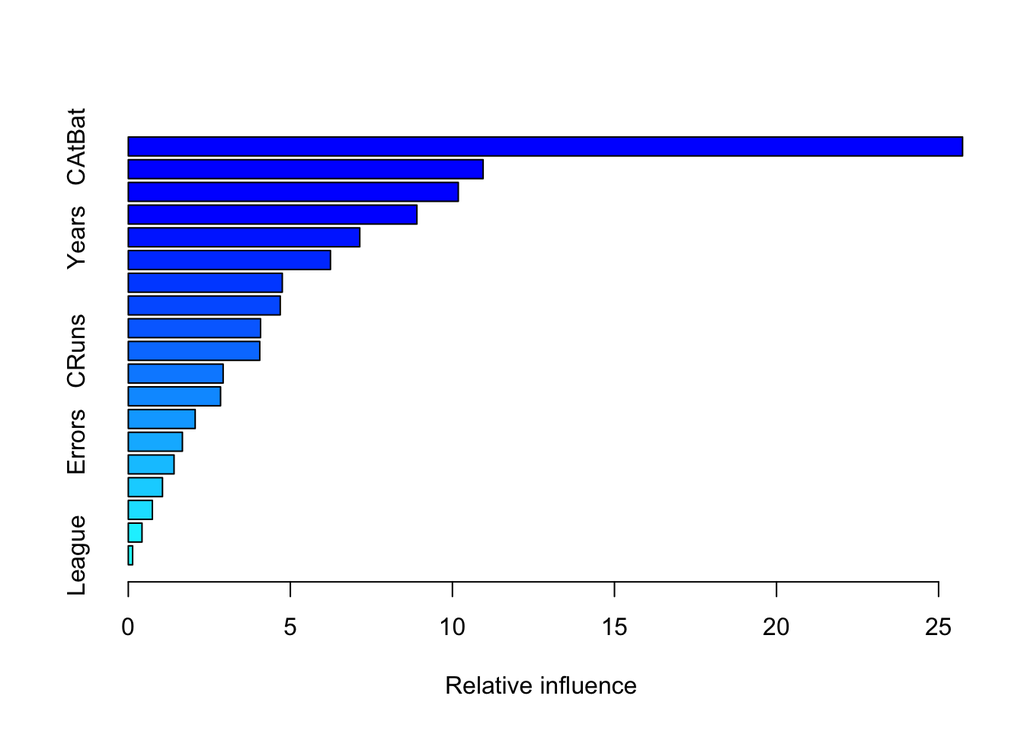

```
##                 var    rel.inf
## CAtBat       CAtBat 25.7398127
## CWalks       CWalks 10.9470933
## CHits         CHits 10.1811801
## CRBI           CRBI  8.9044855
## Years         Years  7.1417590
## CHmRun       CHmRun  6.2373358
## Hits           Hits  4.7515929
## Walks         Walks  4.6881372
## PutOuts     PutOuts  4.0804835
## CRuns         CRuns  4.0560154
## RBI             RBI  2.9262507
## AtBat         AtBat  2.8463555
## HmRun         HmRun  2.0639382
## Errors       Errors  1.6695639
## Assists     Assists  1.4118036
## Runs           Runs  1.0547873
## Division   Division  0.7427251
## NewLeague NewLeague  0.4229875
## League       League  0.1336928
```

```r
set.seed(10)
model5best = gbm(Salary ~ ., data = train, distribution = "gaussian",
                 n.trees = 1000, shrinkage = shrink[which.min(test_MSE)])
summary(model5best)
```

The variables that appear to be the important predictors are `CAtBat`, `CWalks` and `CHits`.

7. Now apply bagging to the training set. What is the test set MSE for this approach?

```r
set.seed(10)
model5bagged = randomForest(Salary ~ ., data = train,
                            mtry = 15, ntree = 100)
predictions = predict(model5bagged, test)
mean((predictions - test$Salary)^2)
```

```
## [1] 0.2233214
```

When bagging, the test set MSE is $0.223$; this is lower than when boosting is used instead.

## Question 11: This question uses the `Caravan` dataset.

1. Create a training set consisting of the first $1,000$ observations and a test set consisting of the remaining observations.

```r
set.seed(11)
df = Caravan
df$Purchase = ifelse(df$Purchase == "Yes", 1, 0)
indices = 1:1000
train = df[indices,]
test = df[-indices,]
```

2. Fit a boosting model to the training set with `Purchase` as the response and the other variables as predictors. Use $1,000$ trees and a shrinkage of $0.01$. Which predictors appear to be the most important?

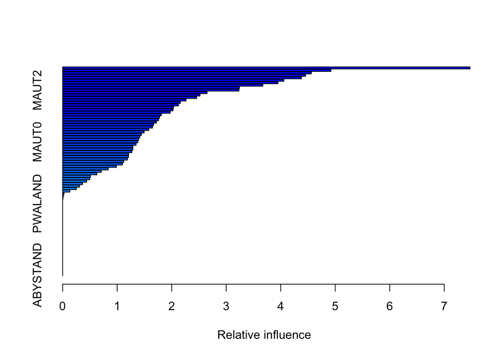

```
##               var     rel.inf
## PPERSAUT PPERSAUT 7.472017283
## MGODGE     MGODGE 4.920268524
## PBRAND     PBRAND 4.562337369
## MKOOPKLA MKOOPKLA 4.455474976
## MOPLHOOG MOPLHOOG 4.380527334
## MOSTYPE   MOSTYPE 4.058244281
## MINK3045 MINK3045 3.950103516
## MGODPR     MGODPR 3.672167279
## MBERMIDD MBERMIDD 3.243664884
## MAUT2       MAUT2 3.234222424
## MBERARBG MBERARBG 2.649691655
## MSKB1       MSKB1 2.519943184
## MSKC         MSKC 2.458311336
## MOPLMIDD MOPLMIDD 2.265387824
## MSKA         MSKA 2.160331133
## PWAPART   PWAPART 2.124682559
## MBERARBO MBERARBO 2.033834610
## MINKM30   MINKM30 2.025470388
## MFWEKIND MFWEKIND 1.973111208
## MRELOV     MRELOV 1.811226920
## MBERHOOG MBERHOOG 1.779508314
## MAUT1       MAUT1 1.761319430
## MRELSA     MRELSA 1.720751942
## MRELGE     MRELGE 1.667203409
## MGODOV     MGODOV 1.649518856
## MINK7512 MINK7512 1.580946746
## MINKGEM   MINKGEM 1.495104835
## MFALLEEN MFALLEEN 1.445414183
## MSKB2       MSKB2 1.417953954
## MZFONDS   MZFONDS 1.395215715
## MAUT0       MAUT0 1.379730933
## MGODRK     MGODRK 1.346956354
## MINK4575 MINK4575 1.289878285
## MFGEKIND MFGEKIND 1.287102544
## ABRAND     ABRAND 1.269977976
## MGEMLEEF MGEMLEEF 1.210600254
## MHHUUR     MHHUUR 1.207518555
## MGEMOMV   MGEMOMV 1.188485795
## MSKD         MSKD 1.120963005
```

[output cut: 31 more lines]

```
## ABESAUT   ABESAUT 0.000000000
## AMOTSCO   AMOTSCO 0.000000000
## AVRAAUT   AVRAAUT 0.000000000
## AAANHANG AAANHANG 0.000000000
## ATRACTOR ATRACTOR 0.000000000
## AWERKT     AWERKT 0.000000000
## ABROM       ABROM 0.000000000
## APERSONG APERSONG 0.000000000
## AGEZONG   AGEZONG 0.000000000
## AWAOREG   AWAOREG 0.000000000
## AZEILPL   AZEILPL 0.000000000
## APLEZIER APLEZIER 0.000000000
## AFIETS     AFIETS 0.000000000
## AINBOED   AINBOED 0.000000000
## ABYSTAND ABYSTAND 0.000000000
```

```r
set.seed(11)
model6 = gbm(Purchase ~ ., data = train, distribution = "bernoulli",
             n.trees = 1000, interaction.depth = 4, shrinkage = 0.01)
summary(model6)
```

The predictors that are most important are: `PPERSAUT`, `MGODGE`, `PBRAND`, `MKOOPKLA` , `MOPLHOOG` and `MOSTYPE`.

3. Use the boosting model to predict the response on the test data. Predict that a person will make a purchase if the estimated probability is greater than $20\%$. Form a confusion matrix. What fraction of the people predicted to make a purchase do in fact make one? How does this compare with the results obtained from applying KNN or logistic regression to this dataset?

```r
probs = predict(model6, test, n.tree = 1000, type = "response")
predictions = ifelse(probs > 0.2, 1, 0)
table(predictions, test$Purchase)
```

```
##
## predictions    0    1
##           0 4346  254
##           1  187   35
```

```r
4346 / nrow(test)
```

```
## [1] 0.9012858
```

Not bad. When using KNN,

```r
set.seed(11)
model6knn = knn(train, test, cl = train$Purchase, k = 5)
table(model6knn, test$Purchase)
```

```
##
## model6knn    0    1
##         0 4504  285
##         1   29    4
```

```r
set.seed(11)
model6log = glm(Purchase ~ ., data = train, family = "binomial")
probs = predict(model6log, test, type = "response")
predictions = ifelse(probs > 0.2, 1, 0)
table(predictions, test$Purchase)
```

```
##
## predictions    0    1
##           0 4183  231
##           1  350   58
```

The fraction of the people predicted to make a purchase goes down when using a logistic regression model.

## Question 12: Apply boosting, bagging and random forests to any dataset. Be sure to fit the models on a training set and to evaluate their performance on a test set. How accurate are the results compared to simple methods like linear or logistic regression? Which of these appraoches yields the best performance?

```r
df = biopsy
df = na.omit(df)
set.seed(12)
df = df %>% subset(select = -ID)
df$class = ifelse(df$class == "malignant", 1, 0)
indices = sample(1:nrow(df), size = 0.7*nrow(df))
train = df[indices,]
test = df[-indices,]
```

Base Tree Model:

```r
set.seed(12)
model_base = tree(class ~ ., train)
predictions = predict(model_base, test, class = "response")
probs = ifelse(predictions > 0.5, 1, 0)
mse_base = (nrow(test) - sum(diag(table(probs, test$class)))) / nrow(test)
mse_base
```

```
## [1] 0.04390244
```

Boosting:

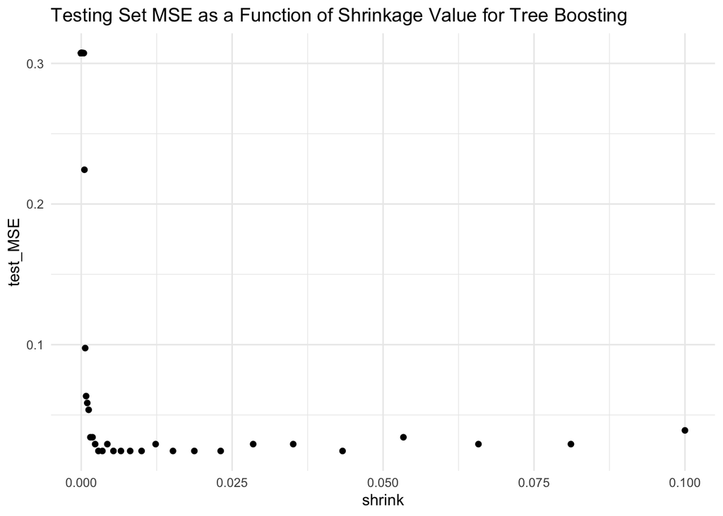

```r
set.seed(12)
shrink = 10^seq(-10, -1, length = 100)
test_MSE = c()
for(i in shrink){
  model_boost = gbm(class ~ ., data = train, distribution = "bernoulli",
                    n.trees = 1000, interaction.depth = 4, shrinkage = i)
  predictions = predict(model_boost, test, n.trees = 1000)
  probs = ifelse(predictions > 0.5, 1, 0)
  score = (nrow(test) - sum(diag(table(probs, test$class)))) / nrow(test)
  test_MSE = c(test_MSE, score)
}
test_MSE_df = data.frame(shrink, test_MSE)
ggplot(test_MSE_df, aes(x = shrink, y = test_MSE)) + geom_point() +
  ggtitle("Testing Set MSE as a Function of Shrinkage Value for Tree Boosting") +
  theme_minimal()
```

Using the best shrinkage value, the test set MSE for a boosting model is

```r
mse_boost = min(test_MSE)
mse_boost
```

```
## [1] 0.02439024
```

Bagging:

```r
set.seed(12)
train$class = as.factor(train$class)
test$class = as.factor(test$class)
model_bag = randomForest(class ~., data = train,
                         mtry = ncol(df)-1, importance = TRUE)
predictions = predict(model_bag, test,
                      n.trees = 1000, type = "response")
probs = ifelse(predictions == 1, 1, 0)
mse_bag = (nrow(test) - sum(diag(table(probs, test$class)))) / nrow(test)
mse_bag
```

```
## [1] 0.02926829
```

Random Forest:

```r
set.seed(12)
test_MSE = c()
for(i in 1:13){
  model_rf = randomForest(class ~., data = train,
                          mtry = i, importance = TRUE)
  predictions = predict(model_rf, test,
                        n.trees = 1000, type = "response")
  probs = ifelse(predictions == 1, 1, 0)
  score = (nrow(test) - sum(diag(table(probs, test$class)))) / nrow(test)
  test_MSE = c(test_MSE, score)
}
```

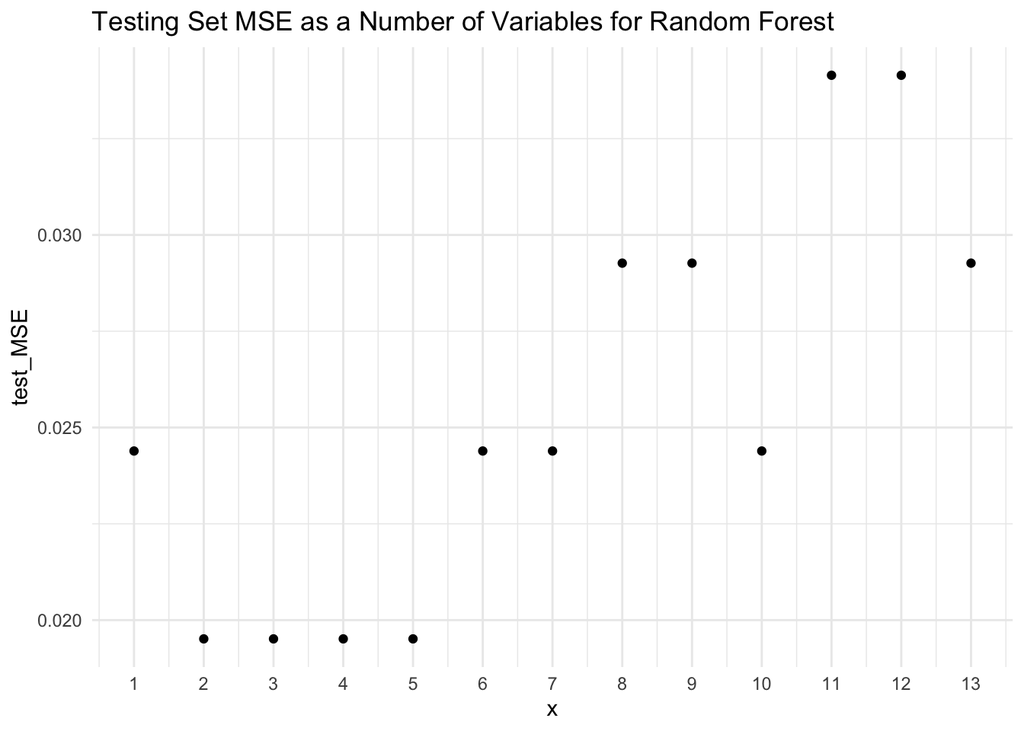

```r
test_MSE_df = data.frame(x = 1:13, test_MSE)
ggplot(test_MSE_df, aes(x = x, y = test_MSE)) + geom_point() +
  scale_x_continuous(breaks = 1:13) +
  ggtitle("Testing Set MSE as a Number of Variables for Random Forest") +
  theme_minimal()
```

The best number of variables to use is

```r
which.min(test_MSE)
```

```
## [1] 2
```

and the respective test set MSE is

```r
mse_rf = min(test_MSE)
mse_rf
```

```
## [1] 0.0195122
```

Alternative, when using KNN, the test set MSE is

```r
set.seed(12)
model_knn = knn(train, test, cl = train$class, k = 5)
mse_knn = (nrow(test) - sum(diag(table(probs, test$class)))) / nrow(test)
mse_knn
```

```
## [1] 0.02926829
```

and when performing logistic regression, the test set MSE is

```r
set.seed(12)
model_log = glm(class ~., data = train, family = "binomial")
probs = predict(model_log, test, type = "response")
predictions = ifelse(probs == 1, 1, 0)
mse_log = (nrow(test) - sum(diag(table(predictions, test$class)))) / nrow(test)
mse_log
```

```
## [1] 0.3073171
```

All the test set MSEs are plotted below. Logistic regression is omitted since its test set MSE is far above the rest.

[figure not shown]

```r
mse_df = data.frame("model" = c("one tree", "boosting",
                                "bagging", "random forest", "knn"),
                    "mse" = c(mse_bag, mse_boost, mse_bag, mse_rf, mse_knn))
ggplot(mse_df, aes(x = reorder(model, mse), y = mse)) +
  geom_col(color = "slateblue4", fill = "slateblue1") +
  labs(x = "model", y = "test set MSE") +
  ggtitle("Test Set MSE using Various Tree Approaches and other Classification Models") +
  theme_minimal()
```

All of the practice applied exercises in this document are taken from “An Introduction to Statistical Learning, with applications in R” (Springer, 2013) with permission from the authors: G. James, D. Witten, T. Hastie and R. Tibshirani.